# Lecture Lab 1

Leon Eyrich Jessen

2026

# Course Introduction

## DATADATADATA: Data Hoarding

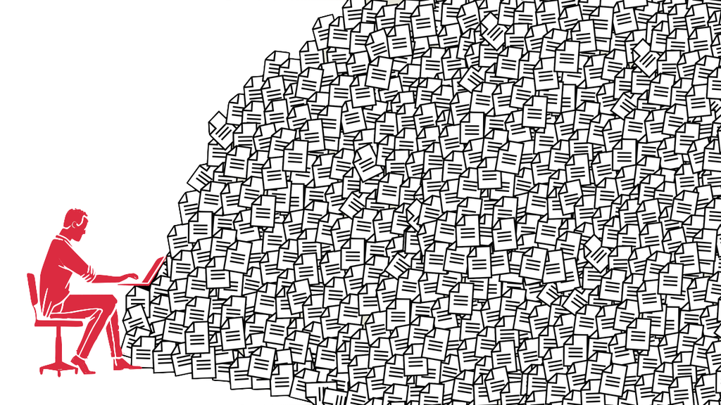

## Increasing the Value of Data Requires Activation!

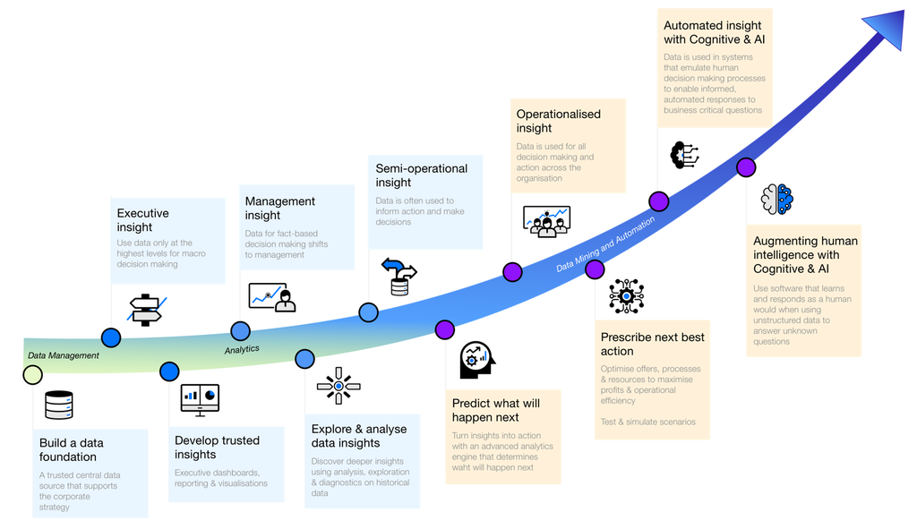

## Data Driven Decision Making

*Because we’ve always done it this way!*

Your job as a Bio Data Scientist:

- Activate data
- Extract insights
- Communicate to non-data stakeholders
- Facilitate data driven decision making

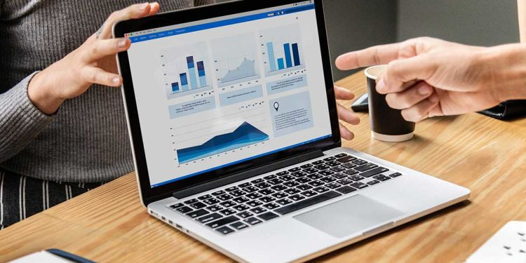

*Levering data driven decision making allows the company to gain a competitive edge and this is where you Bio Data Science skills are indispensable!*

## You value as a Bio Data Scientist / Bioinformatician

- In your career, your task will be to create value
- This is regardless of whether you plan to work in indstry or pursue a research career
- What you do has to create value
- Creating value requires skills
- Skills need to be learned
- So, why are you here?

[figure not shown]

# You’re here to gain skills, which will allow you to generate value!

## R for Bio Data Science - What is it?

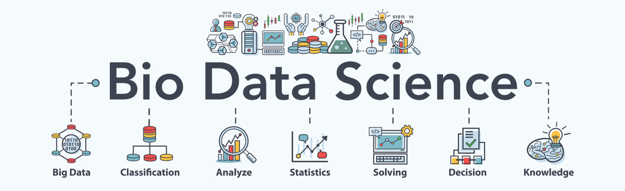

- In essence: The art of converting numbers to value
  - Ingest data
  - Transform, wrangle, visualise, model
  - Output insights

## R for Bio Data Science - Intrinsically interdisciplinary

[figure not shown]

## Why “Bio” in R for Bio Data Science?

[figure not shown]

## What is the motivation for this Course?

[figure not shown]

## What is the motivation for this Course?

[figure not shown]

## What will you learn?

- The craft of going from raw extracted data to insights
- Advanced data visualisation
- Collaborative project oriented coding
- All with an emphasis on reproducibility and communication

# R

## Introducing R: A Journey into Bio Data Science

- Open-source programming language
- Essential tool for statistics & data visualization
- Widely used in bioinformatics and data science
- Dynamic community & vast library of packages

*“To understand computations in R, two slogans are helpful: Everything that exists is an object. Everything that happens is a function call.” – John Chambers (creator of the S language, of which R is an implementation).*

## The Roots and Rise of R

- Originated from the ‘S’ language at Bell Laboratories in the 1970s
- S was proprietary, so basically R is an open source implementation of S and was officially released in 1995
- This similar to Linux vs. Unix
- A leader in statistical computing. Powers many academic research & industry projects
- E.g. Crucial in genomics, where R aids in decoding biological data
- R comes with a very large and well proven built in tools for data analysis

## A Few Examples of Functional Programming

You can approach `R` as

- an object-oriented programming language

Let’s say we have this vector

```r
my_vector <- c(49, 31, 24, 35, 71, 7, 36, 23, 67, 37)
```

Now, we want to compute the mean, we can do:

Object Oriented Approach:

```r
Vector <- R6::R6Class("Vector",
  public = list(
    data = NULL,
    initialize = function(data) {
      if (!is.numeric(data)) {
        stop("Data should be numeric.")
      }
      self$data <- data
    },
    mean = function() {
      return(sum(self$data) / length(self$data))
    }
  )
)
numbers <- Vector$new(my_vector)
print(numbers$mean())
```

```
[1] 38
```

## A Few Examples of Functional Programming

You can approach `R` as

- an object-oriented programming language
- a imperative programming language

Let’s say we have this vector

```r
my_vector <- c(49, 31, 24, 35, 71, 7, 36, 23, 67, 37)
```

Now, we want to compute the mean, we can do:

Imperative Approach:

```r
my_sum <- 0
for( i in 1:length(my_vector) ){
  my_sum <- my_sum + my_vector[i]
}
my_mean <- my_sum / length(my_vector)
print(my_mean)
```

```
[1] 38
```

## A Few Examples of Functional Programming

You can approach `R` as

- an object-oriented programming language
- a imperative programming language
- a functional programming language

The code on the right all performs the same task, but which do you think is:

- simpler to read and understand?
- faster to execute?

In this course we will work with `R` in its native form - a fully fledged functional programming language

Let’s say we have this vector

```r
my_vector <- c(49, 31, 24, 35, 71, 7, 36, 23, 67, 37)
```

Now, we want to compute the mean, we can do:

Functional approach:

```r
my_mean <- mean(my_vector)
print(my_mean)
```

```
[1] 38
```

## You simply call functions on objects

Standard Deviation

```r
sd(my_vector)
```

```
[1] 19.70899
```

Median

```r
median(my_vector)
```

```
[1] 35.5
```

Permute

```r
sample(my_vector)
```

```
 [1] 36 31  7 23 71 67 49 35 24 37
```

Bootstrap

```r
sample(my_vector, replace = TRUE)
```

```
 [1]  7 31 35 67 31 35 71 24 23 49
```

…and tons more!

## “R is not a real programming language”: Debunking Myths I

1. `R` is Turing-complete:
   - `R` can theoretically solve any computational problem. Foundational concept shared with e.g. Python, C++, Java, etc.
2. R is fully capable in Production:
   - E.g. shiny apps used in industry and `R` comes with an ecosystem supporting reproducibility in production settings.
3. Comprehensive Ecosystem:
   - CRAN contains ~20,000 packages. Also Bioconductor is a gold standard for bioinformatics software.
4. Interoperability:
   - Seamless integration with other languages (C, C++, Fortran, and Python) using packages like Rcpp and reticulate.

## “R is not a real programming language”: Debunking Myths II

5. Advanced Programming Features:
   - Supports object-oriented, functional, and imperative programming paradigms. Flexible metaprogramming with capabilities like non-standard evaluation
6. R’s Active & Growing Community:
   - Annual global R conferences and numerous local user groups and also: `tidyverse`
7. Performance:
   - `R` is interpreted and can be slower, packages like data.table and Rcpp offer dramatic performance enhancements. Also, parallel computing is straightforward
8. Not Just for Statisticians:
   - R’s applications range from web development to machine learning (tidymodels, caret, mlr3) to reporting (Quarto, bookdown)

*Closing Thought: Every tool has its strengths. The key is to understand and leverage them effectively.*

# Tidyverse

## Tidyverse

- With SO many packages, there will inevitable be SO many opinions
- The tidyverse is a unified opinionated collection of R packages designed for data science
- All packages share an underlying design philosophy, grammar, and data structures
- Today R has in essense become two dialects `base` and `tidyverse`
- Note: This course will focus solely on the `tidyverse` dialect

[figure not shown]

*We’ll spend a lot more time on going over the details of the Tidyverse!*

## Intermezzo: A brief course History

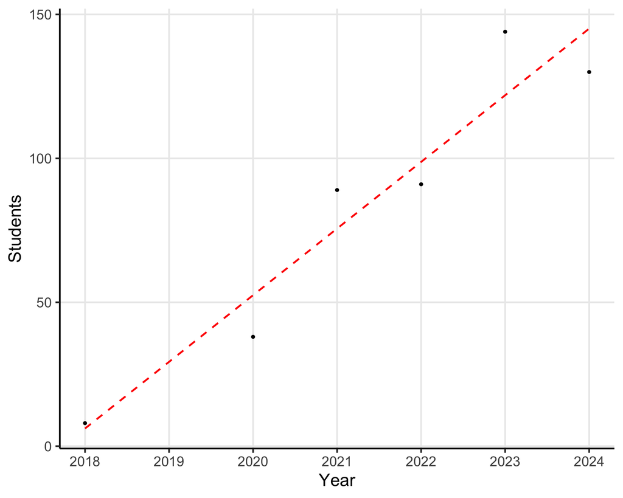

## General Course Outline

Tuesdays 08.00 - 12.00

- 08.00 - 08.30 Recap of key points from last weeks exercises
- 08.30 - 08.45 Introduction to theme of the day
- 08.45 - 09.00 Break
- 09.00 - 12.00 Exercises

## About

### Course Description

- Basically, what can you expect to learn and what do I expect that you learn: [DTU Course Base](https://kurser.dtu.dk/course/22100)

### Course Resources

- Text Book: [“R for Data Science 2e”](https://r4ds.hadley.nz) by Hadley Wickham, Mine Çetinkaya-Rundel, and Garrett Grolemund
- Course site: https://r4bds.github.io

### Course format

- Active Learning: *Very strong emphasis on students working in groups*, rather than me talking
- The focus is on you working actively, *not* me talking
- I will *not* go through all preparation materials in class
- Proper preparation is a prerequisite for completing lab exercises and maximising course yield
- I focus on supporting your independence, hence for some exercises you will have to seek out information (*I’m not a good data scientist, I’m just slightly better at googling than others*)

## Exercise feedback

### Weekly

- An exercise question will be highlighted
- Each group is responsible for crafting an answer to this highlighted question
- These answers will be hand-ins
- The following week, we will choose a random answer to be discussed in plenum
- Note: This starts from lab 2

## Group Formation

- Modern Bio Data Science is a team sport!
- You have to form a group of 4-5 students with a Shared Bio Data Science / Bioinformatics Area of Interest
- You will work in these groups throughout the course
- You will do the final project in these groups
- You will attend the exam in these groups
- Group work is a *very important* meta skill for an engineer!
- Please fill in groups, see schedule for lab 1
- If you do not have a group, fill in your id and interest at an available group and someone might join you
- I aim to let you decide on the groups, I will of course be happy to help if needed

## How to succeed in this course

- Prepare materials as instructed!
- Show up for class!
- Do the exercises!
- Do the project work!

*Basically, show up, follow the curriculum and you will do fine!*